# IMT 573: PSet 2 - Data cleaning and plotting

Madhusmita Oke

# Collaborators

- Madhusmita

# Setup

Do whatever setup you do here, such as loading libraries

```r
# Load standard libraries
library("tidyverse")
library(dplyr)
library(ggplot2)
```

# 1 Covid-19 Data

## 1.1 Load a single month of African data

```r
df_africa <- read.csv("/Users/madhusmitaoke/MSIM-Academic/DataScience/IMT573-DSI/data/ps-3/covid/countries-africa.csv.bz2", sep = "\t")
dim(df_africa)
```

```
## [1] 58  5
```

```r
names(df_africa)
```

```
## [1] "rank"       "country"    "population" "year"       "source"
```

```r
head(df_africa, 2)
```

```
##   rank  country  population year                          source
## 1    1  Nigeria 206,139,589 2020                 Worldometers[3]
## 2    2 Ethiopia 109,224,414 2018 UN population projections[4][5]
```

```r
list_african_countries <- unique(df_africa$country)
#list_african_countries
cat("Number of African countries:",length(list_african_countries))
```

```
## Number of African countries: 58
```

```r
all_files <- list.files(path = "/Users/madhusmitaoke/MSIM-Academic/DataScience/IMT573-DSI/data/ps-3/covid/", pattern = "covid-global_*")
all_files
```

```
##  [1] "covid-global_01-01-2021.csv.bz2" "covid-global_02-01-2020.csv.bz2"
##  [3] "covid-global_02-01-2021.csv.bz2" "covid-global_03-01-2020.csv.bz2"
##  [5] "covid-global_03-01-2021.csv.bz2" "covid-global_04-01-2020.csv.bz2"
##  [7] "covid-global_04-01-2021.csv.bz2" "covid-global_05-01-2020.csv.bz2"
##  [9] "covid-global_05-01-2021.csv.bz2" "covid-global_06-01-2020.csv.bz2"
## [11] "covid-global_06-01-2021.csv.bz2" "covid-global_07-01-2020.csv.bz2"
## [13] "covid-global_07-01-2021.csv.bz2" "covid-global_08-01-2020.csv.bz2"
## [15] "covid-global_08-01-2021.csv.bz2" "covid-global_09-01-2020.csv.bz2"
## [17] "covid-global_09-01-2021.csv.bz2" "covid-global_10-01-2020.csv.bz2"
## [19] "covid-global_10-01-2021.csv.bz2" "covid-global_11-01-2020.csv.bz2"
## [21] "covid-global_12-01-2020.csv.bz2"
```

```r
cat("Total number of files:",length(list.files(path = "/Users/madhusmitaoke/MSIM-Academic/DataScience/IMT573-DSI/data/ps-3/covid/", pattern = "covid-global_*")))
```

```
## Total number of files: 21
```

```r
df_global_oct_21 <- read.csv("/Users/madhusmitaoke/MSIM-Academic/DataScience/IMT573-DSI/data/ps-3/covid/covid-global_10-01-2021.csv.bz2", sep = "\t")
dim(df_global_oct_21)
```

```
## [1] 4004   14
```

```r
names(df_global_oct_21)
```

```
##  [1] "FIPS"                "Admin2"              "Province_State"
##  [4] "Country_Region"      "Last_Update"         "Lat"
##  [7] "Long_"               "Confirmed"           "Deaths"
## [10] "Recovered"           "Active"              "Combined_Key"
## [13] "Incident_Rate"       "Case_Fatality_Ratio"
```

```r
#unique(df_global_oct_21$Country_Region)

#unique(df_global_oct_21$Province_State)


df_common_african_countries <- df_global_oct_21 %>%
  filter(df_global_oct_21$Country_Region %in% list_african_countries)

common_countries <- df_common_african_countries$Country_Region


uncommon_countries <-   df_africa %>%
filter(!(df_africa$country %in% common_countries))

#unique(df_global_oct_21$Country_Region)
head(df_global_oct_21, 4)
```

```
##   FIPS Admin2 Province_State Country_Region          Last_Update      Lat
## 1   NA                          Afghanistan 2021-10-02T04:21:25Z 33.93911
## 2   NA                              Albania 2021-10-02T04:21:25Z 41.15330
## 3   NA                              Algeria 2021-10-02T04:21:25Z 28.03390
## 4   NA                              Andorra 2021-10-02T04:21:25Z 42.50630
##      Long_ Confirmed Deaths Recovered Active Combined_Key Incident_Rate
## 1 67.70995    155191   7206        NA     NA  Afghanistan      398.6581
## 2 20.16830    170778   2705        NA     NA      Albania     5934.3248
## 3  1.65960    203517   5815        NA     NA      Algeria      464.1098
## 4  1.52180     15222    130        NA     NA      Andorra    19701.0289
##   Case_Fatality_Ratio
## 1           4.6433105
## 2           1.5839277
## 3           2.8572552
## 4           0.8540271
```

```r
cat("African countries in covid data :", length(common_countries) ," \n")
```

```
## African countries in covid data : 49
```

```r
cat("African Countries not matched with COVID data:\n")
```

```
## African Countries not matched with COVID data:
```

```r
print(uncommon_countries$country)
```

```
## [1] "Democratic Republic of the Congo"
## [2] "Ivory Coast"
## [3] "Republic of the Congo"
## [4] "Réunion (France)"
## [5] "Western Sahara"
## [6] "Cape Verde"
## [7] "Mayotte (France)"
## [8] "São Tomé and Príncipe"
## [9] "Saint Helena, Ascension and Tristan da Cunha (UK)"
```

We should pay more attention to Democratic Republic of the Congo , Ivory Coast and Republic of the Congo because these are the densely populated countries out of the 9 unmatched countries! As a result, we cannnot miss out insights for these 3 countries (rank 3,16,39); whereas other unmatched countries have less population and rank lower, so would not affect our analysis significantly.

```r
df_global_oct_21$Country_Region <- replace(df_global_oct_21$Country_Region, df_global_oct_21$Country_Region == "Congo (Brazzaville)", "Republic of the Congo")

df_global_oct_21$Country_Region <- replace(df_global_oct_21$Country_Region, df_global_oct_21$Country_Region == "Congo (Kinshasa)", "Democratic Republic of the Congo")

df_global_oct_21$Country_Region <- replace(df_global_oct_21$Country_Region, df_global_oct_21$Country_Region == "Cote d'Ivoire", "Ivory Coast")
```

```r
df_common_african_countries2 <- df_global_oct_21 %>%
  filter(df_global_oct_21$Country_Region %in% list_african_countries)

#df_common_african_countries2
common_countries2 <- df_common_african_countries2$Country_Region


uncommon_countries2 <-   df_africa %>%
filter(!(df_africa$country %in% common_countries2))

uncommon_countries2$country
```

[output not shown]

## 1.2 Load and Merge all data sets

extracting date from file name:

```r
# try extracting date from file name:
file_name <- "covid-global_02-01-2021.csv.bz2"
datepart <- unlist(strsplit(file_name, "[_.]"))[2]

#datepart
date <- as.Date(datepart, format = "%m-%d-%y")
print(date)
```

```
## [1] "2020-02-01"
```

Actual Merging of Data files for African countries with helper functions

```r
# Function to unify Country_Region column across alll global covid data
correct_country_column <- function(df_country) {
  df_country <- df_country %>%
    mutate(Country_Region = Country.Region) %>%
    select(-Country.Region)

  return(df_country)
}
```

```r
# Function to correct names of African countries across global data
replace_african_country_names <- function(df_tbd) {
  if ("Country.Region" %in% names(df_tbd)) {
    df_tbd <- correct_country_column(df_tbd)
  }
  df_tbd$Country_Region <-
    replace(
      df_tbd$Country_Region,
      df_tbd$Country_Region == "Congo (Brazzaville)",
      "Republic of the Congo"
    )

  df_tbd$Country_Region <-
    replace(
      df_tbd$Country_Region,
      df_tbd$Country_Region == "Congo (Kinshasa)",
      "Democratic Republic of the Congo"
    )

  df_tbd$Country_Region <-
    replace(df_tbd$Country_Region,
            df_tbd$Country_Region == "Cote d'Ivoire",
            "Ivory Coast")

  return (df_tbd)
}
```

```r
# Function to add year and month to the data
add_year_month <- function(df_x, date_obj) {
  year_to_add <- format(date_obj, "%Y")
  month_to_add <- format(date_obj, "%m")
  df_x <- df_x %>%
    mutate(Year = year_to_add) %>%
    mutate(Month = month_to_add)

  return(df_x)
}
```

```r
# Function to extract date from file name
get_date_obj <- function(file_name_with_date) {
  datepart <- unlist(strsplit(file_name_with_date, "[_.]"))[2]

  date <- as.Date(datepart, format = "%m-%d-%Y")
  return(date)
}
```

```r
# Function to Extract only AFrican countries from global data
extract_african_countries <- function(df_all_countries) {
  df_african_countries <- df_all_countries %>%
    filter(df_all_countries$Country_Region %in% list_african_countries)

  return(df_african_countries)
}
```

```r
# Function for Filtering all data step wise using above functions
filter_africa_dataset <- function(df_x, date_obj) {
  df_x <- replace_african_country_names(df_x)
  df_x <- extract_african_countries(df_x)
  df_x <- add_year_month(df_x, date_obj)
  df_temp <- df_x %>%
    select(Country_Region, Deaths, Year, Month)
  return(df_temp)
}
```

Looping Over all files to get AFrican countries Covid -19 data

```r
df_africa_final <-
  data.frame(
    Country_Region = c(),
    Deaths = c(),
    Year = c(),
    Month = c()
  )
base_path <-
  "/Users/madhusmitaoke/MSIM-Academic/DataScience/IMT573-DSI/data/ps-3/covid/"

for (global_file in all_files) {

  df_temp <- read.csv(paste0(base_path, global_file), sep = "\t")

  date_obj <- get_date_obj(global_file)

  df_temp <- filter_africa_dataset(df_temp, date_obj)

  #df_africa_final <- merge(df_africa_final, df_temp, all = TRUE)
  df_africa_final <- rbind(df_africa_final, df_temp)
}
# finally AFrican Covid data is ready for analysis :displaying dim for reference
dim(df_africa_final)
```

```
## [1] 986   4
```

```r
names(df_africa_final)
```

```
## [1] "Country_Region" "Deaths"         "Year"           "Month"
```

## 1.3 Display time series

Manipulate population to numeric value for calculations ahead

```r
#df_africa$population
#typeof(df_africa$population)

df_africa$population <- as.numeric(gsub(",", "", df_africa$population))

typeof(df_africa$population)
```

```
## [1] "double"
```

Deaths per Million summary -

```r
df_africa_final_pop <- df_africa_final %>%
  group_by(Country_Region) %>%
  summarise(total_deaths = sum(Deaths)) %>%
  mutate(country = Country_Region) %>%
  select(-Country_Region)

#df_africa_final_pop

df_deaths <- df_africa_final_pop %>% left_join(df_africa, by = "country") %>% mutate( Deaths_per_mill = (total_deaths/population)*1000000)  %>% select(total_deaths, population, country, Deaths_per_mill)

head(df_deaths, 2)
```

```
## # A tibble: 2 × 4
##   total_deaths population country Deaths_per_mill
##          <int>      <dbl> <chr>             <dbl>
## 1        48608   43000420 Algeria           1130.
## 2         9009   24383301 Angola             369.
```

Finding 10 worst death rates for African countries

```r
df_deaths2 <- df_deaths %>%
  arrange(desc(Deaths_per_mill))

ten_worst_deaths <- df_deaths2 %>%
  slice_head(n = 10)

ten_worst_deaths
```

```
## # A tibble: 10 × 4
##    total_deaths population country      Deaths_per_mill
##           <int>      <dbl> <chr>                  <dbl>
##  1       140651   10982754 Tunisia               12807.
##  2       674600   59956820 South Africa          11251.
##  3         7767    1119375 Eswatini               6939.
##  4        15026    2280700 Namibia                6588.
##  5        33070    5298152 Libya                  6242.
##  6          460      90945 Seychelles             5058.
##  7        10116    2024904 Botswana               4996.
##  8       111624   37034729 Morocco                3014.
##  9         1574     864618 Djibouti               1820.
## 10        23250   13061239 Zimbabwe               1780.
```

Plotting death rate over time for the top-10 African countries:

```r
df_africa_final_2 <- df_africa_final %>%
  mutate(country = Country_Region) %>%
  select(-Country_Region)



df_africa_final_3 <- df_africa_final_2 %>% left_join(ten_worst_deaths, by= "country") %>% mutate(date = as.Date(paste(df_africa_final_2$Year, df_africa_final_2$Month,"01", sep="-"))) %>%
  filter(!is.na(total_deaths))




df_temp <- df_africa_final_3 %>% group_by(country, date) %>%
   summarise(death_rate = (sum(Deaths)/population) * 1000000)
```

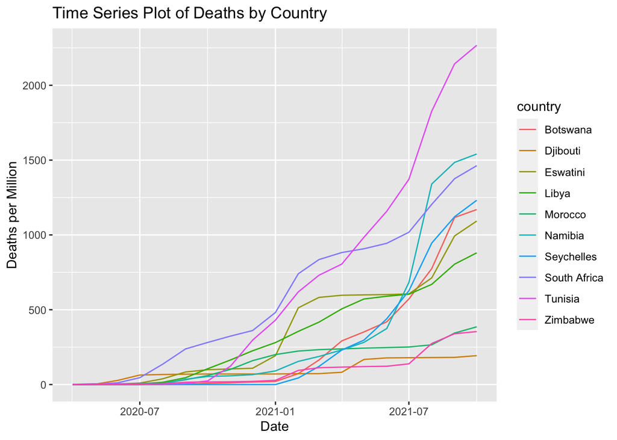

```r
plot_1 <- ggplot(df_temp, aes(x = date, y = death_rate, color = country, fill= country  )) +
  geom_line() +
  labs(
    title = "Time Series Plot of Deaths by Country",
    x = "Date",
    y = "Deaths per Million"
  )

plot_1
```

Death Rate over a Month for the countries - Calculated deaths per million grouping by year, month , country (here `df_5`)

```r
df_5 <- df_africa_final_3 %>%
  group_by(country, Year, Month) %>%
  mutate(monthly_death_rate = (sum(Deaths)/population) * 1000000)

head(df_5, 5)
```

```
## # A tibble: 5 × 9
## # Groups:   country, Year, Month [5]
##   Deaths Year  Month country  total_deaths population Deaths_per_mill date
##    <int> <chr> <chr> <chr>           <int>      <dbl>           <dbl> <date>
## 1     42 2021  01    Botswana        10116    2024904           4996. 2021-01-01
## 2     61 2021  01    Djibouti         1574     864618           1820. 2021-01-01
## 3    216 2021  01    Eswatini         7767    1119375           6939. 2021-01-01
## 4   1487 2021  01    Libya           33070    5298152           6242. 2021-01-01
## 5   7425 2021  01    Morocco        111624   37034729           3014. 2021-01-01
## # ℹ 1 more variable: monthly_death_rate <dbl>
```

```r
df_africa_final_3_new <- df_africa_final_3[order(df_africa_final_3$country, df_africa_final_3$Year, df_africa_final_3$Month),]

agg_data_df <-  df_africa_final_3_new %>% group_by(country, Year, Month) %>%
  summarise(monthly_deaths = sum(Deaths)) %>%
  mutate(monthly_new_deaths = monthly_deaths - lag(monthly_deaths, default = first(monthly_deaths)))
agg_data_df <- agg_data_df %>%
  mutate(timeVariable = as.Date(paste(Year, Month,"01", sep="-")))

head(agg_data_df, 5)
```

```
## # A tibble: 5 × 6
## # Groups:   country, Year [1]
##   country  Year  Month monthly_deaths monthly_new_deaths timeVariable
##   <chr>    <chr> <chr>          <int>              <int> <date>
## 1 Botswana 2020  04                 1                  0 2020-04-01
## 2 Botswana 2020  05                 1                  0 2020-05-01
## 3 Botswana 2020  06                 1                  0 2020-06-01
## 4 Botswana 2020  07                 1                  0 2020-07-01
## 5 Botswana 2020  08                 2                  1 2020-08-01
```

Plotting death trend over month - to identify any Covid-19 waves. We can observe agg_data_df to see that deaths are varying over months within an year.

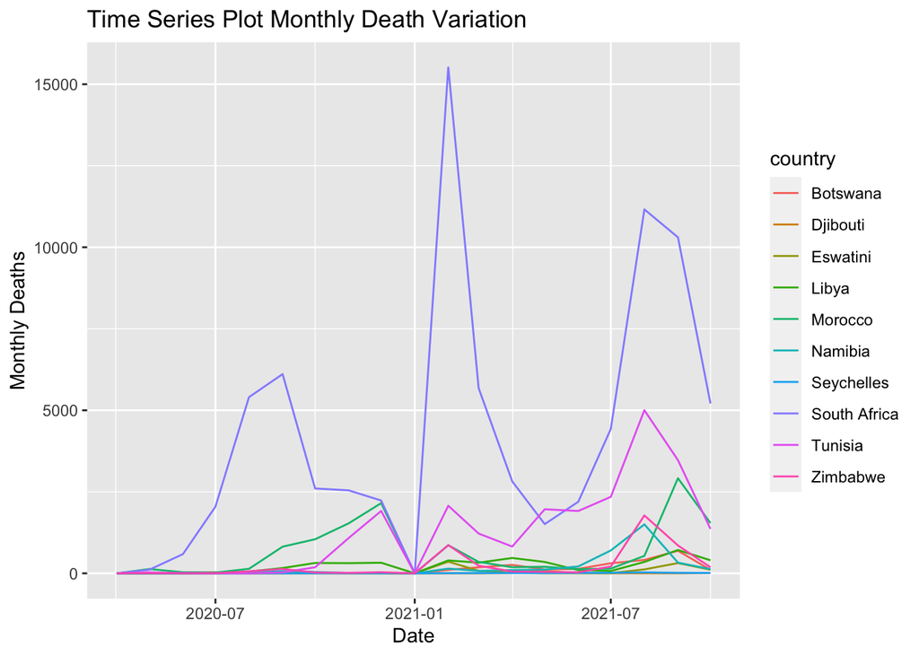

```r
plot_2 <- ggplot(agg_data_df, aes(x = timeVariable, y = monthly_new_deaths, color = country, fill= country  )) +
  geom_line() +
  labs(
    title = "Time Series Plot Monthly Death Variation",
    x = "Date",
    y = "Monthly Deaths"
  )

plot_2
```

Approximately, there are 3 major covid-19 waves seen in the death variation analysis (see South Africa, Tunisia, Libya…)

## 1.4 Think about this

### 1.4.1 Where would the US be on the top-10 list of African countries?

Based on the internet / other news report readings, I think US would rank in atleast top 5 of the top-10 list of African countries.

### 1.4.2 What do you think about reliability of these data?

Based on online search/readings, COVID-19 reliability of data is highly likely to be far from reality. There may have been many covid-19 cases which were not reported and didnt make it into the data. It is very likely to happen in developing countries from African continent. On the contrary, if high level of testing was done in parts of say US - the death number and covid-19 cases would show a higher number.

In addition, there may have been mortality cases due to allied causes i.e. indirectly caused by covid-19 illness like heart attack which may not have been captured. For reasons such as political pressure, lack of awareness- much of the data related to covid-19 deaths might not have made it to the research data in question!

### 1.4.3 What recommendations would you give to the data collection team related to how the data is collected and store? Think about variable names, variable coding, structure of data files, and everything else you struggled with in this problem set. But also mention what is done well.

Some Recommendations to the data collection team : Variable names such as Country_Region could have been constant across all global data files leading to less effort in aggregation

Variable encoding of variable such as Country_Region could have to constant for global covid data and African country names data! For Example : The name of country - Republic of the Congo being same everywhere would have prevented a lot of confusion!

Data could have been presented with specific variable date -for more credibility and reducing aggregation effort

What was done well? - Monthly organization of files (over 2020 and few of 2021) for global covid data and African country data with names and population.

There were no garbage or NA values/ character values in crucial columns such as country, deaths etc

Data type formatting was good, column names although not constant were intuitive to understand

Looking at reference links of data sources, the team did good job in collating data from varied credible sources.

Lastly, I took 8-10 hours for completing the assignment until this point. Most time spent on the monthly deaths trend with lag and mutate